# Synthetic data

## Simpsons Paradox

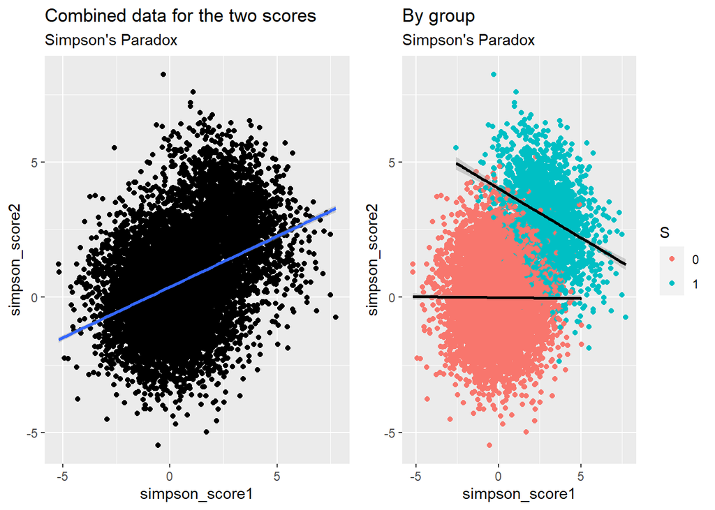

```r
# link the mean of simpson score 1 with the other features
# mean1 <- sqrt(proxy)+rnorm(1)

mu<-c(0,0)
sigma<-rbind(c(2,-0.1),c(0,2) )
Males<-as.data.frame(mvrnorm(n=length(M), mu=mu, Sigma=sigma))

mu<-c(3,3)
sigma<-rbind(c(2,-0.7),c(-0.7,2) )
Females<-as.data.frame(mvrnorm(n=length(Fem), mu=mu, Sigma=sigma))

# Contenitori
dd$simpson_score1 <- vector(mode="numeric",length = nrow(dd))
dd$simpson_score2 <- vector(mode="numeric",length = nrow(dd))

dd$simpson_score1[which(dd$S==0)] <- Males[,1]
dd$simpson_score2[which(dd$S==0)] <- Males[,2]
dd$simpson_score1[which(dd$S==1)] <- Females[,1]
dd$simpson_score2[which(dd$S==1)] <- Females[,2]


# the combined data
gg1 <- dd%>%ggplot(aes(x=simpson_score1, y=simpson_score2))+geom_point()+
  geom_smooth(method='lm')+
  ggtitle("Combined data for the two scores","Simpson's Paradox")

# by group
gg2 <- dd%>%ggplot(aes(x=simpson_score1, y=simpson_score2, group=S, col=S))+
  geom_point()+ geom_smooth(method='lm', col='black')+
  ggtitle("By group","Simpson's Paradox")

# Plot Simpson's paradox
ggarrange(gg1,gg2)
```

```r
# creo vettori che serviranno per costruire variabile target
# simpson_score1 <- dd$simpson_score1
# simpson_score2 <- dd$simpson_score2
```

## TARGET VARIABLE

La variabile target dovrà dipendere dalle feature indipendenti $X$, dalle features protette $S$ e dalle sue proxy. La variabile target potrà essere sia binaria (conveniente al fine d). Nella definizione della variabile target non utilizzo la protected feature $S$, utilizzo piuttosto le proxy.

Nella formula inserisci tutte le variabili che sono importanti per definire l’output comprese quelle definite esternamente a defData (se usi simstudy) poi crea dataframe finale con tutte le variabili.

Di seguito la definizione della variabile $Z$ che entrerà nella invlogit ($pr = 1/(1+exp(-z))$).

$$\begin{equation}
\pi_i=P(Y_i=1|x_i)=\frac{exp(x_i'\beta)}{1+exp(x_i'\beta)}
\end{equation}$$
Linear combination with a BIAS:
$$\begin{equation}
\hat{Z}=\beta*interview + \beta_1*score +
\beta_2*Github.account-\beta_3*age+\beta_4*X.score
\\ +\beta_5*simpson.score1+\beta_6*simpson.score2+\beta_7*proxy+\beta_8*proxy2+\mu \end{equation}$$

prova a centrare e scalare i regressori prima di generare l’output in modo che tutte le variabili abbiano lo stesso peso. Il paradosso di Simpson entra come termine di interazione all’interno dei regressori, sono stati fatti diversi tentativi con $\beta$ diversi, l’idea è di stare sotto la soglia di 0.8 per la misura di Disparate Impact.

```r
# outcome binario

z = 1.5*(dd$X_score/110)+0.7*dd$interview+0.4*dd$score-0.3*dd$simpson_score1*dd$simpson_score2 - 0.4*dd$age + 0.4*dd$Github_account + 1.2*(dd$proxy2^2) - 0.4*dd$proxy
pr = 1/(1+exp(-z))         # pass through an inv-logit function
Y = rbinom(n,1,pr)      # bernoulli response variable

#now feed it to glm:
df = data.frame(dd,Y)
# controlla i segni e che non ci siano troppi beta=0
glm(Y ~.,data=df,family="binomial")
```

```
##
## Call:  glm(formula = Y ~ ., family = "binomial", data = df)
##
## Coefficients:
##    (Intercept)              S1       interview  Github_account           proxy
##       -3.08465        -1.59287         0.66023         0.24555        -0.36392
##         proxy2             age         X_score           score  simpson_score1
##        0.36791        -0.29592         0.02546         0.37717        -0.04417
## simpson_score2
##       -0.05395
##
## Degrees of Freedom: 9999 Total (i.e. Null);  9989 Residual
## Null Deviance:       12060
## Residual Deviance: 7563  AIC: 7585
```

```r
summary(df$Y)
```

```
##    Min. 1st Qu.  Median    Mean 3rd Qu.    Max.
##   0.000   0.000   0.000   0.291   1.000   1.000
```

```r
table(df$Y)
```

```
##
##    0    1
## 7090 2910
```

Per fare variable selection e non utilizzare i $\beta=0$ si possono usare tecniche di sparse modeling (e.g. Lasso https://aldosolari.github.io/SL/)

## Assign Treatment

Last step of the synthetic data creation, treatments could be additional protected features or just noise in the model training. Il trattamento potrebbe anche essere sbilanciato, stratificato per genere etc.. utilizzo pacchetto simstudy e funzione trtAssign

```r
dt <- as.data.table(df)

dt <- trtAssign(dt, nTrt = 3, balanced = TRUE,strata="S")
# back to data.frame
df <- as.data.frame(dt)
```

## Controlli

controlla che a dataset formato si preservi paradosso di Simpson, diversa distribuzione di Github account per genere etc…

```r
df$age <- round(df$age) # età usiamo interi
df$X_score <- round(df$X_score) # idem
df$S <- ifelse(df$S==1,1,0) # from factor to numeric
str(df) # all numeric
```

```
## 'data.frame':    10000 obs. of  12 variables:
##  $ S             : num  0 0 0 0 0 0 0 0 0 0 ...
##  $ interview     : int  7 2 9 5 3 12 3 6 5 1 ...
##  $ Github_account: int  1 0 0 0 1 1 0 1 0 1 ...
##  $ proxy         : num  1.917 1.594 1.277 0.521 1.249 ...
##  $ proxy2        : num  0.0885 0.0684 0.0582 0.2886 0.0398 ...
##  $ age           : num  22 22 23 22 22 23 23 24 22 22 ...
##  $ X_score       : num  100 101 105 96 107 98 110 105 108 96 ...
##  $ score         : int  7 2 6 6 7 10 3 9 8 8 ...
##  $ simpson_score1: num  0.495 2.6 0.698 1.035 0.538 ...
##  $ simpson_score2: num  1.07 -2.53 3.64 -2.15 1.97 ...
##  $ Y             : int  0 0 0 0 0 1 0 0 0 0 ...
##  $ trtGrp        : int  3 2 2 1 2 1 3 2 1 1 ...
```

```r
head(df)
```

```
##   S interview Github_account     proxy     proxy2 age X_score score
## 1 0         7              1 1.9174931 0.08850297  22     100     7
## 2 0         2              0 1.5940949 0.06838342  22     101     2
## 3 0         9              0 1.2772139 0.05820192  23     105     6
## 4 0         5              0 0.5206696 0.28859022  22      96     6
## 5 0         3              1 1.2493250 0.03983581  22     107     7
## 6 0        12              1 3.0244749 0.02036770  23      98    10
##   simpson_score1 simpson_score2 Y trtGrp
## 1      0.4953760     1.07028205 0      3
## 2      2.5996513    -2.53349772 0      2
## 3      0.6979309     3.64083501 0      2
## 4      1.0350677    -2.14587274 0      1
## 5      0.5379374     1.97354996 0      2
## 6      0.3387071     0.01041267 1      1
```

```r
xtabs(Github_account ~ S, df)
```

```
## S
##    0    1
## 3104  479
```

```r
table(df$S, df$Github_account)
```

```
##
##        0    1
##   0 4824 3104
##   1 1593  479
```

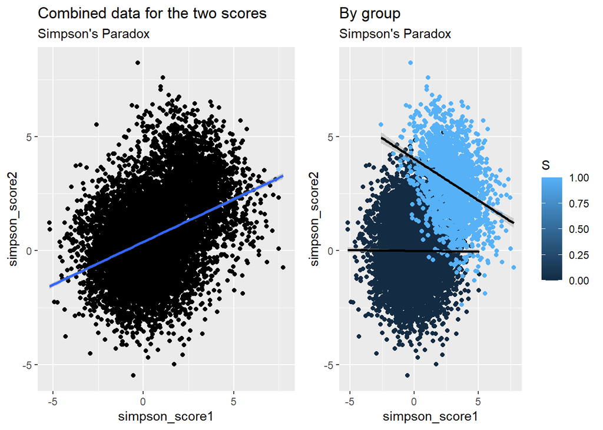

```r
# preservato simpson's score
# the combined data
gg1 <- df%>%ggplot(aes(x=simpson_score1, y=simpson_score2))+geom_point()+
  geom_smooth(method='lm')+
  ggtitle("Combined data for the two scores","Simpson's Paradox")

# by group
gg2 <- df%>%ggplot(aes(x=simpson_score1, y=simpson_score2, group=S, col=S))+
  geom_point()+ geom_smooth(method='lm', col='black')+
  ggtitle("By group","Simpson's Paradox")

# Plot Simpson's paradox
ggarrange(gg1,gg2)
```

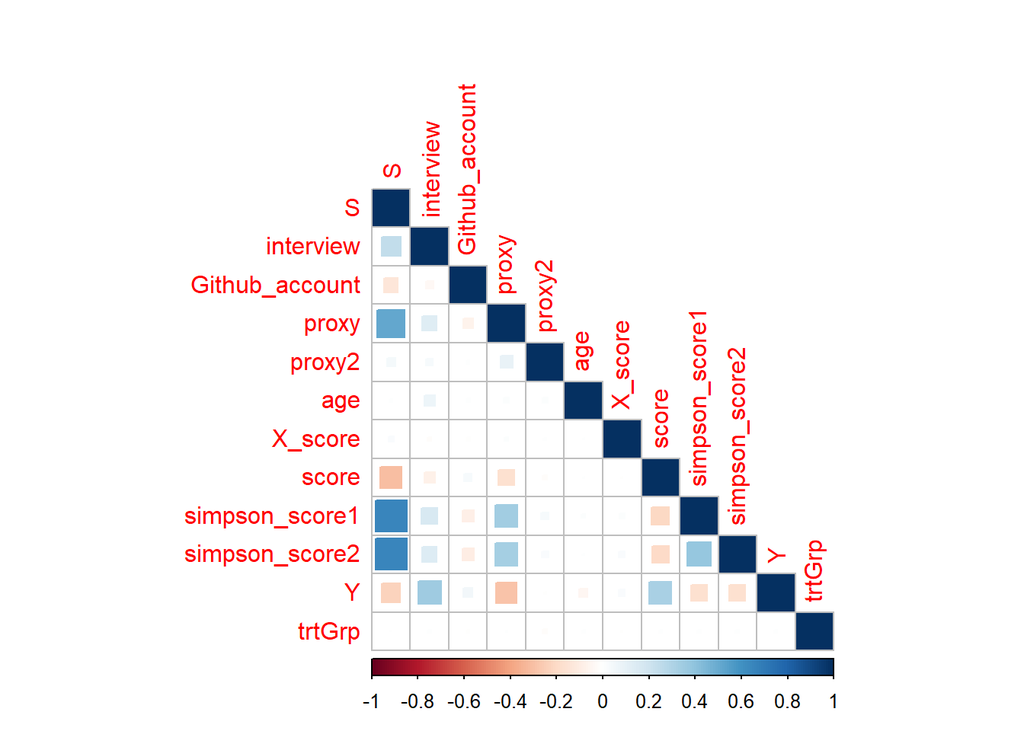

```r
# correlations

correlation <- cor(df)
corrplot::corrplot(correlation,method = "square",type="lower")
```

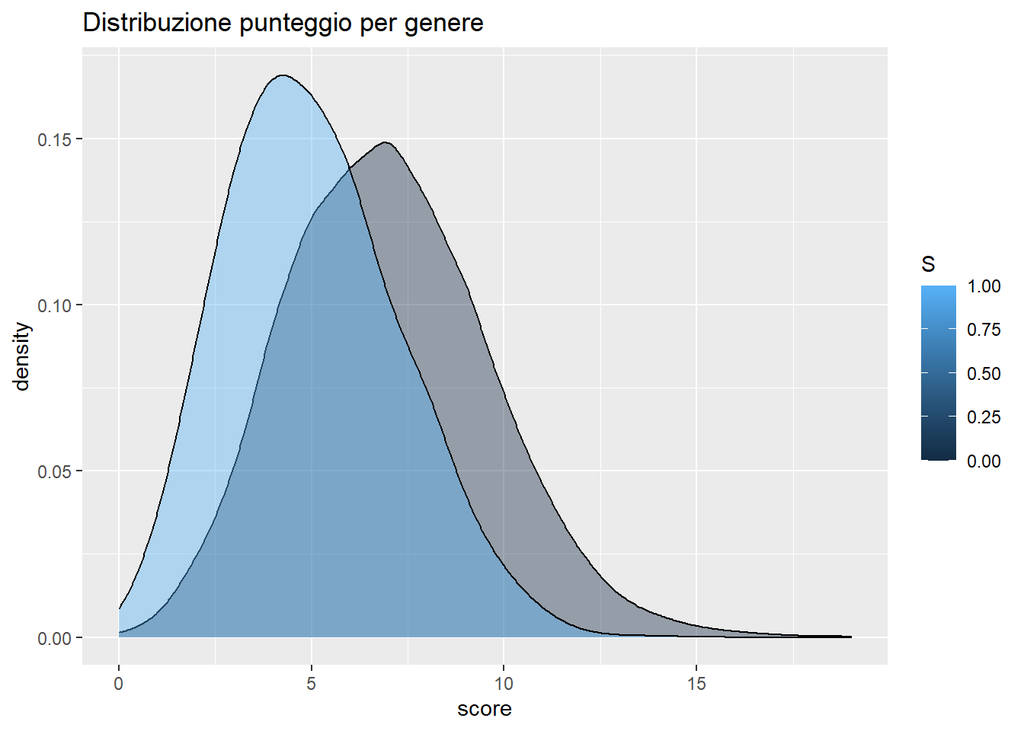

```r
# Controllo che sia preservata la differenza tra le scores che dipendono
p2 <- ggplot(data=df, aes(x=score, group=S, fill=S),col=c(3,4)) +
  geom_density(adjust=1.5, alpha=.4) +
  ggtitle("Distribuzione punteggio per genere")
p2
```

## BIAS IN DATA

Statistical Parity difference e Disparate impact sono misure del BIAS all’interno del Dataset verso una protected feature. $S$ è la protected feature, $S_a$ è la privileged class mentre $S_d$ è l’unprivileged class; $Y$ rappresenta l’outcome che assume valore 1 per l’outcome positivo (preferibile) e valore 0 per l’outcome “negativo” (non necessariamente).

$$\begin{equation}
SPD=P(Y=1|S=S_d)-P(Y=1|S=S_a)=0
\end{equation}$$

Una volta individuata la sensitive feature $S$ e l’outcome binario $Y$ che assume valore 1 se preferibile e 0 se non preferibile, si calcola:
$$\begin{equation}
\frac{P(Y=1|S=S_d)}{P(Y=1|S=S_a)} \geq 0.8
\end{equation}$$

La seguente funzione rappresenta un adattamento del codice in python fornito in “Responsible AI” per il calcolo del BIAS verso una protected feature, prende in input dataset, feature protetta con gruppo svantaggiato e avvantagiato, outcome (BINARIO) e outcome preferibile. in output SPD e DI.

```r
Stat_parity_test <- function(data,protected_group,Sa_label,Sd_label,Y,fav_label){

  # data = dataset anche in formato "data.table" (from simstudy)
  # protected_group = "feature_protetta
  # Sa_label,Sd_label = Gruppo avvantagiato e scantaggiato della feature protetta
  # Y = outcome binario
  # fav_label = outcome preferibile/positivo

  data <- as.data.frame(data) # data frame
  # Privileged class
  Sa <- data[data[,protected_group]==Sa_label,]
  # Privileged class with positive outcome
  Fav_Sa <- Sa[Sa[,Y]==fav_label,]
  Fav_Sa_count <- nrow(Fav_Sa)

  # Disadvantaged group
  Sd <- data[data[,protected_group]==Sd_label,]
  # Disadvantaged group with positive outcome
  Fav_Sd <- Sd[Sd[,Y]==fav_label,]
  Fav_Sd_count <- nrow(Fav_Sd)

  Advantageous <- nrow(Sa)
  dis_advantageous <- nrow(Sd)

  statistical_parity_difference = (Fav_Sd_count/dis_advantageous)-(Fav_Sa_count/Advantageous)
  Disparate_impact = (Fav_Sd_count/dis_advantageous)/(Fav_Sa_count/Advantageous)

  return(list("SPD"=statistical_parity_difference,"DI"=Disparate_impact))

}
```

SPD e DI

Utilizzo la classe minoritaria come favorita, sd esempio 0 potrebbe indicare non esclusione dal colloquio funturo/ no churning poi si ricodifica eventualmente

```r
Stat_parity_test(data=df,protected_group = "S",Sa_label=0,Sd_label=1,Y="Y",fav_label=1)
```

```
## $SPD
## [1] -0.2574766
##
## $DI
## [1] 0.2522805
```

```r
# setwd("C:/Users/Davide Zulato/Desktop/Sim_Data")
# write.csv(df,file = "BIASED_data_11_11_22.csv")
```

## Run a classifier

Una volta generato il dataset e salvato in .csv Inizion con un modello Random forest e verifico che la confusion matrix sia BIASED come i dati di training

```r
# Libraries
library("DALEX") # per model explanation (see tmwr cap 18)
library("ranger")
library("ggplot2")
library("rms")
library(hexbin)
library(ggpubr)
library(parsnip)
library(tidymodels)
library(rpart)
library(caret)
library(randomForest)
library("e1071")
```

carico il dataset creato e divido in training e test set stratificando per la variabile risposta, controlla anche la distribuzione della feature sensibile

```r
# df <- read.csv("BIASED_data.csv")

## Spending our data
set.seed(123)
data_split <- initial_split(df, prop = 0.80, strata = Y) #campionamento stratificato per la variabile risposta
# se non stratifico rischio di non fare buone previsioni (ad esempio potrei avere tutte le costose nel test set)
data_train <- training(data_split)
data_test  <- testing(data_split)
dim(data_train)
```

```
## [1] 8000   12
```

```r
dim(data_test)
```

```
## [1] 2000   12
```

```r
# controllo se è preservata la distribuzione per genere tra train e test
prop.table(table(data_train$S))
```

```
##
##        0        1
## 0.793125 0.206875
```

```r
prop.table(table(data_test$S))
```

```
##
##      0      1
## 0.7915 0.2085
```

## Train classification models

```r
# Random forest
model_ranger <- ranger(Y ~ ., data = data_train,
                       classification = TRUE, probability = TRUE)

# logistic regression model
model_rms <- lrm(Y ~ ., data = data_train)

# support vector machine
model_svm <- svm(Y ~ ., data = data_train,
                 type = "C-classification", probability = TRUE)
```

Dopo aver allenato i modelli, utilizzando anche parsnip e tidy modeling with r crea explainer per model explanation locale e globale. Biecek, Przemyslaw, and Tomasz Burzykowski. 2021. Explanatory Model Analysis. Chapman; Hall/CRC, New York. https://ema.drwhy.ai/.

```r
# Data should be passed without a target column

exp_ranger <- DALEX::explain(model_ranger,
                      data = data_train[,-11], # train without Y
                      y = data_train$Y)
```

```
## Preparation of a new explainer is initiated
##   -> model label       :  ranger  (  default  )
##   -> data              :  8000  rows  11  cols
##   -> target variable   :  8000  values
##   -> predict function  :  yhat.ranger  will be used (  default  )
##   -> predicted values  :  No value for predict function target column. (  default  )
##   -> model_info        :  package ranger , ver. 0.14.1 , task classification (  default  )
##   -> predicted values  :  numerical, min =  0 , mean =  0.2925984 , max =  0.9852475
##   -> residual function :  difference between y and yhat (  default  )
##   -> residuals         :  numerical, min =  -0.6286587 , mean =  -0.001598413 , max =  0.6686508
##   A new explainer has been created!
```

```r
# prediction for the first observation
predict(exp_ranger, data_train[1,])
```

```
##         1
## 0.1771479
```

```r
# Explainer for SVM
exp_svm <- DALEX::explain(model_svm,
                      data = data_train[,-11],
                      y = data_train$Y)
```

```
## Preparation of a new explainer is initiated
##   -> model label       :  svm  (  default  )
##   -> data              :  8000  rows  11  cols
##   -> target variable   :  8000  values
##   -> predict function  :  yhat.svm  will be used (  default  )
##   -> predicted values  :  No value for predict function target column. (  default  )
##   -> model_info        :  package e1071 , ver. 1.7.11 , task classification (  default  )
##   -> predicted values  :  numerical, min =  0.01581091 , mean =  0.2899955 , max =  0.9983521
##   -> residual function :  difference between y and yhat (  default  )
##   -> residuals         :  numerical, min =  -0.9904753 , mean =  0.001004472 , max =  0.965528
##   A new explainer has been created!
```

```r
predict(exp_svm, data_train[1,])
```

```
## [1] 0.3733072
```

```r
# with more arguments
exp_rms <- DALEX::explain(model_rms,
                   data = data_train[,-11],
                   y = data_train$Y,
                   predict_function = function(m, x)
                     predict(m, x, type = "fitted"),
                   label = "Logistic with splines")
```

```
## Preparation of a new explainer is initiated
##   -> model label       :  Logistic with splines
##   -> data              :  8000  rows  11  cols
##   -> target variable   :  8000  values
##   -> predict function  :  function(m, x) predict(m, x, type = "fitted")
##   -> predicted values  :  No value for predict function target column. (  default  )
##   -> model_info        :  package rms , ver. 6.3.0 , task classification (  default  )
##   -> predicted values  :  numerical, min =  0.0001075924 , mean =  0.291 , max =  0.9993897
##   -> residual function :  difference between y and yhat (  default  )
##   -> residuals         :  numerical, min =  -0.9721635 , mean =  -9.833539e-14 , max =  0.9992715
##   A new explainer has been created!
```

```r
#
# 5. The adapter stores some useful information about the model

exp_rms$model_info
```

```
## Package: rms
## Package version: 6.3.0
## Task type: classification
```

```r
#
# 6. First step in the exploration are measures of performance
# performance is calculated on data in explainer
# use update_data to set a new dataset

mp_ranger <- model_performance(exp_ranger)
mp_ranger # AUC prossima a 1, sospetta
```

```
## Measures for:  classification
## recall     : 0.9128007
## precision  : 0.9819778
## f1         : 0.9461264
## accuracy   : 0.96975
## auc        : 0.9982943
##
## Residuals:
##           0%          10%          20%          30%          40%          50%
## -0.628658730 -0.235457540 -0.146224286 -0.092450797 -0.057282987 -0.033101587
##          60%          70%          80%          90%         100%
## -0.015109460 -0.001463844  0.163250000  0.325114054  0.668650794
```

```r
mp_rms <- model_performance(exp_rms)
mp_rms
```

```
## Measures for:  classification
## recall     : 0.6198454
## precision  : 0.7411402
## f1         : 0.6750877
## accuracy   : 0.826375
## auc        : 0.8828252
##
## Residuals:
##            0%           10%           20%           30%           40%
## -0.9721635365 -0.3896186309 -0.2241833520 -0.1241998747 -0.0664481919
##           50%           60%           70%           80%           90%
## -0.0332108752 -0.0114075764 -0.0009011272  0.2229043312  0.5462466647
##          100%
##  0.9992714525
```

```r
mp_svm <- model_performance(exp_svm)
mp_svm
```

```
## Measures for:  classification
## recall     : 0.6305842
## precision  : 0.8026244
## f1         : 0.7062786
## accuracy   : 0.847375
## auc        : 0.9071177
##
## Residuals:
##          0%         10%         20%         30%         40%         50%
## -0.99047525 -0.28143033 -0.16176576 -0.11159754 -0.08046638 -0.06002384
##         60%         70%         80%         90%        100%
## -0.04444239 -0.02418838  0.16655153  0.53334895  0.96552803
```

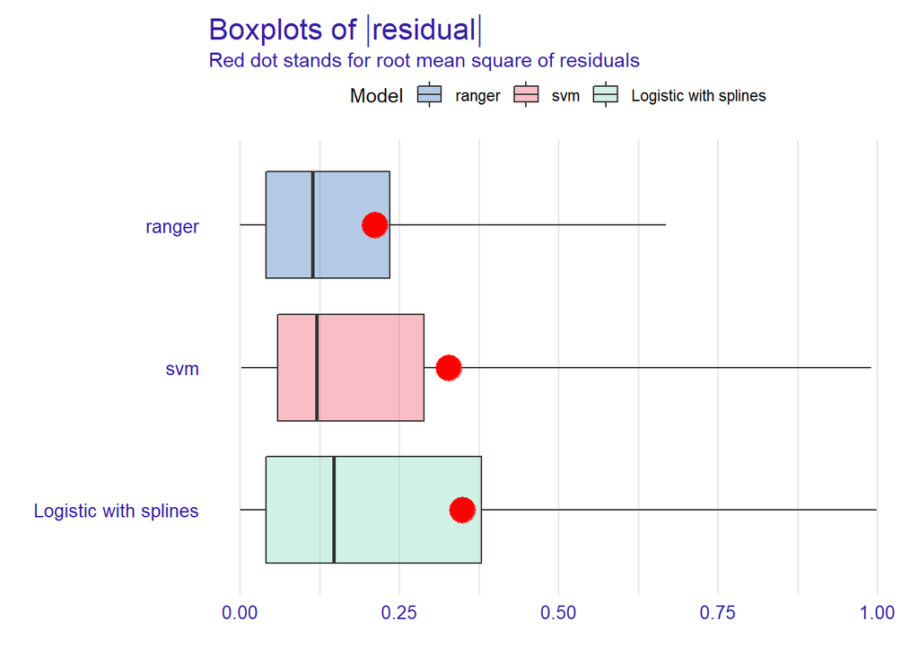

```r
#
# 7. it is easier to compare models with charts

plot(mp_ranger, mp_rms,mp_svm, geom = "boxplot")
```

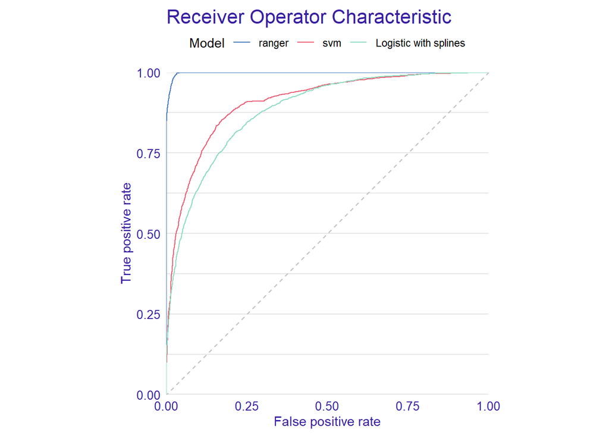

```r
plot(mp_ranger, mp_rms,mp_svm, geom = "roc")
```

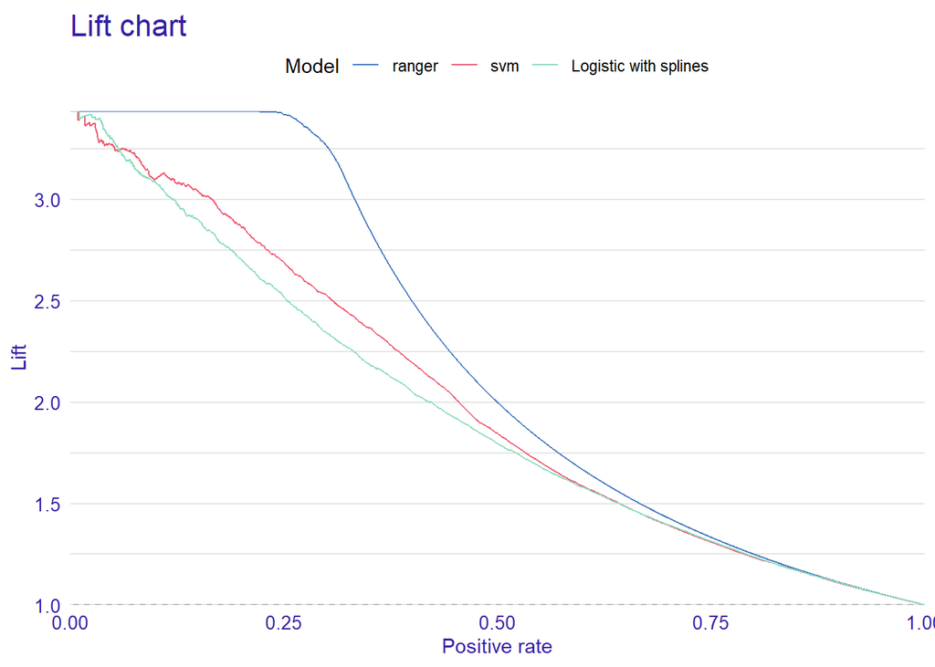

```r
plot(mp_ranger, mp_rms,mp_svm, geom = "lift")
```

```r
#
# 8. Let's focus on a single observations
# loro sono interessanti
# data_train[which(data_train$S==1 & data_train$Y==0),]
Sara<- data_train[7933,]
Sara
```

```
##      S interview Github_account    proxy    proxy2 age X_score score
## 9089 1        10              0 5.065935 0.2432689  22     101     6
##      simpson_score1 simpson_score2 Y trtGrp
## 9089       2.659244       2.167112 1      2
```

```r
predict(exp_ranger, Sara)
```

```
##         1
## 0.4165819
```

## Variable attributions - Shapley values (Instance-level explanation)

Un approccio per la model explanation è la break-down explanation, attraverso la funzione DALEX predict_parts(); it computes how contributions attributed to individual features change the mean model’s prediction for a particular observation (tmwr). SHapley Additive exPlanations (SHAP) sono basate su “Shapley values” sviluppate da Shapley nel 1953 nel contesto della cooperative game theory. SHAP is an acronym for a method designed for predictive models.(https://ema.drwhy.ai/)

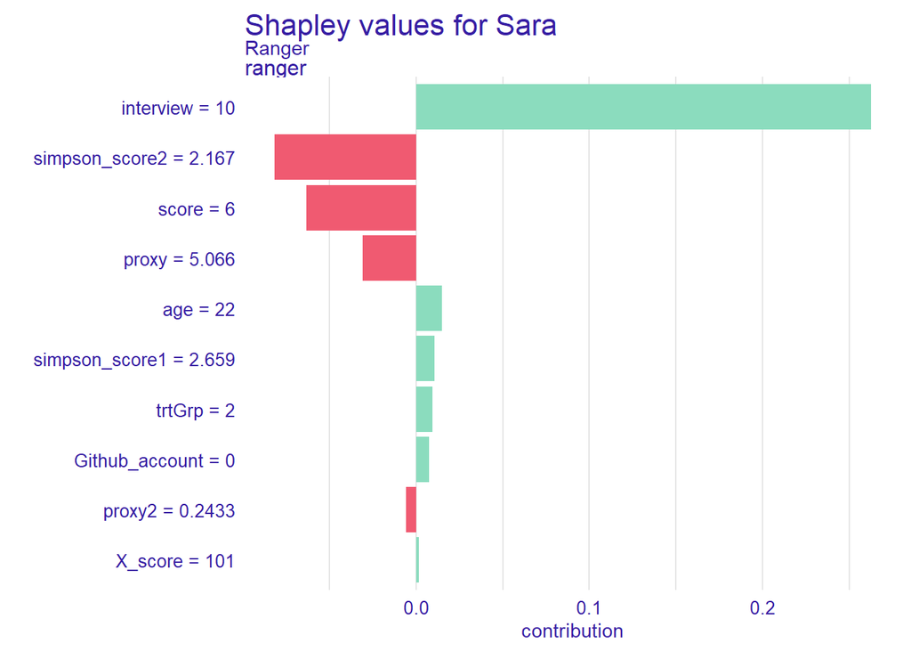

```r
# 9. Variable attributions - Shapley values
# Ranger
sh_ranger <- predict_parts(exp_ranger, Sara,
                           type = "shap", B = 1)

plot(sh_ranger, show_boxplots = FALSE) +
   ggtitle("Shapley values for Sara","Ranger")
```

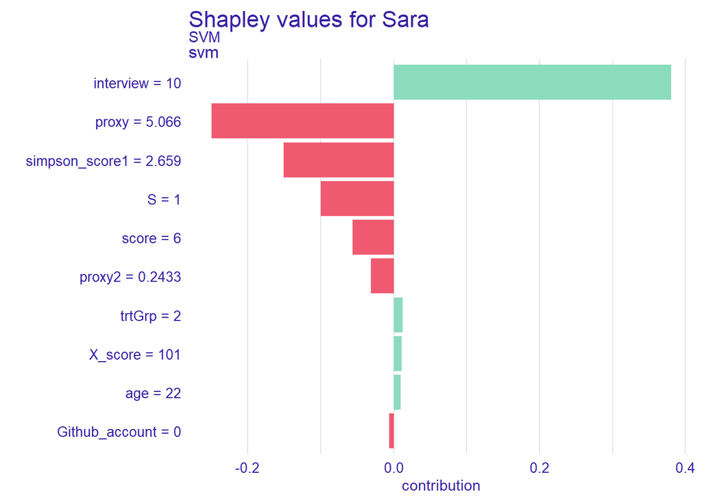

```r
# SVM
sh_SVM <- predict_parts(exp_svm, Sara,
                           type = "shap", B = 1)

plot(sh_SVM, show_boxplots = FALSE) +
   ggtitle("Shapley values for Sara","SVM")
```

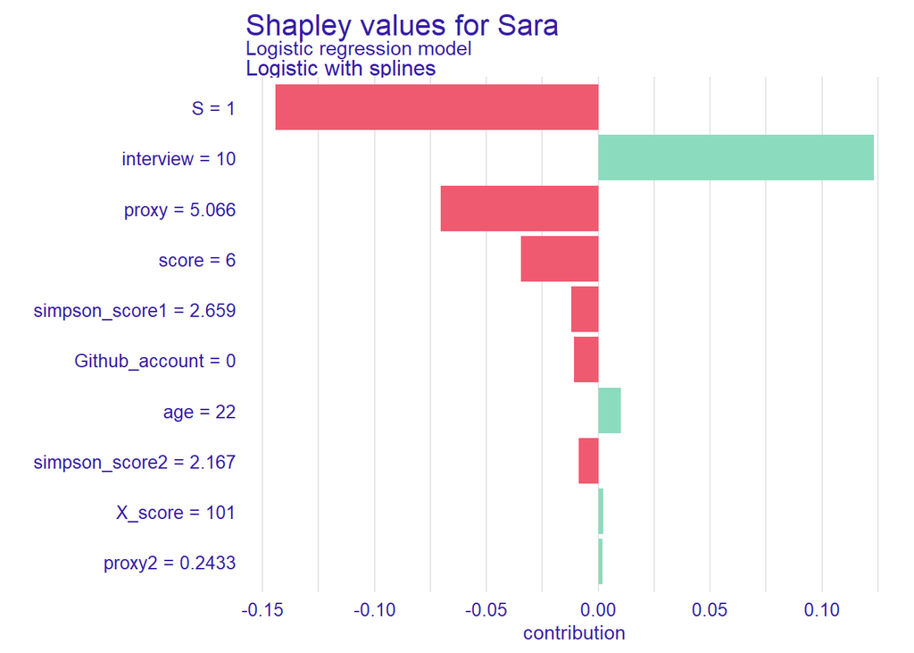

```r
# Logistic Regression Model
sh_rms <- predict_parts(exp_rms, Sara,
                           type = "shap", B = 1)

plot(sh_rms, show_boxplots = FALSE) +
   ggtitle("Shapley values for Sara","Logistic regression model")
```

Gli Shapley values permettono di decomporre le previsioni di un modello nei suoi contributi additivi delle variabili esplicative. vale la pena osservare se i segni dei contributi corrispondono alla costruzione della variabile target.

An important drawback of Shapley values is that they provide additive contributions (attributions) of explanatory variables. If the model is not additive, then the Shapley values may be misleading (ema.drwhy.ai). Ad esempio potrebbe non cosgliere i termini di interazione che abbiamo introdotto nella generazione della variabile target.

## Vaiable Attributions

Variable attributions - Break-down with specified order, tengo lo stesso ordine di colnames() ma posso anche scegliere.

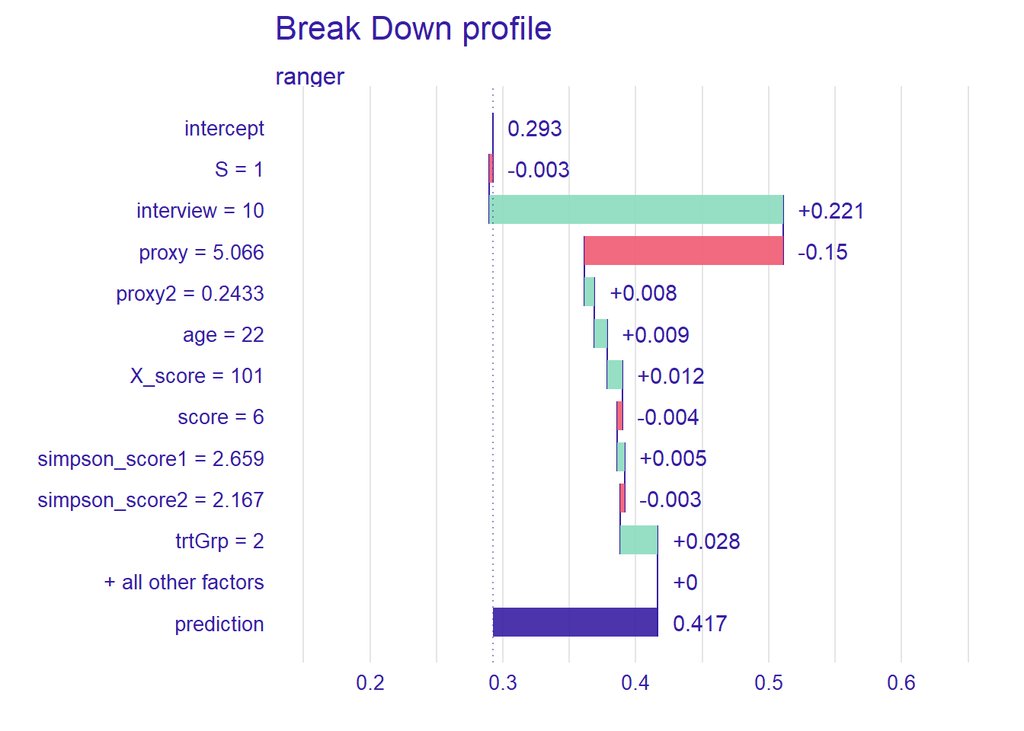

```r
# 11. Variable attributions - Break-down with specified order

bd_ranger <- predict_parts(exp_ranger, Sara,
            order = colnames(df))

plot(bd_ranger)
```

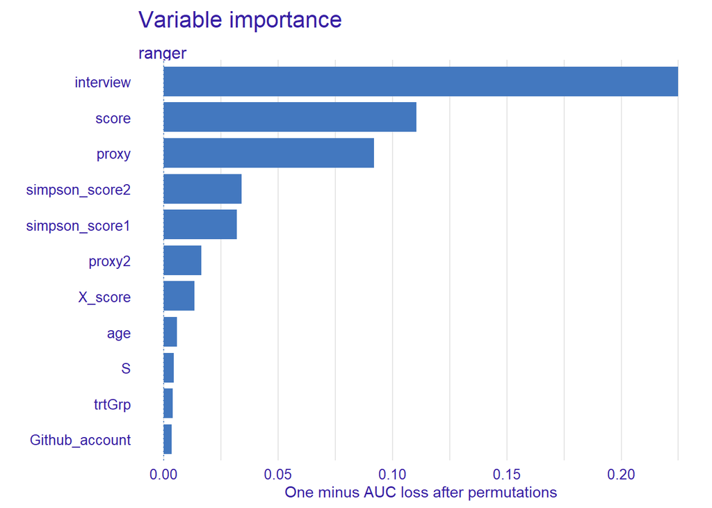

```r
#
# 11. Variable importance

mp_ranger <- model_parts(exp_ranger, type = "difference")

plot(mp_ranger, show_boxplots = FALSE) +
  ggtitle("Variable importance","")
```

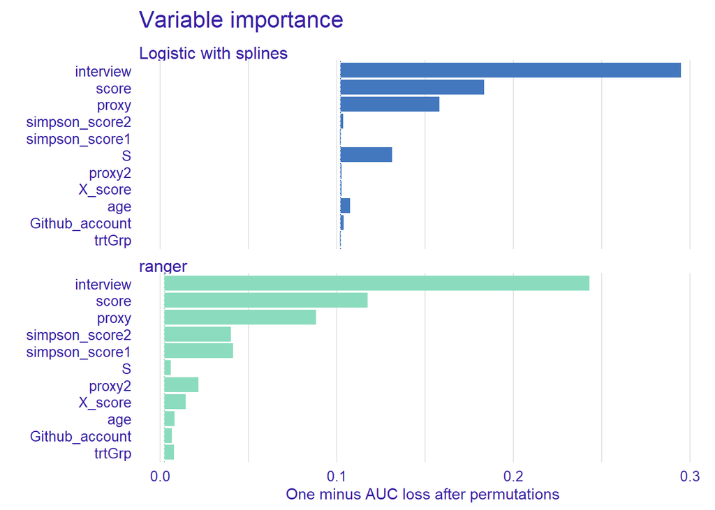

```r
#
# 12. Variable importance for two models

mp_ranger <- model_parts(exp_ranger, B = 1)

mp_rms <- model_parts(exp_rms, B = 1)

plot(mp_ranger, mp_rms, show_boxplots = FALSE, bar_width = 5) +
  ggtitle("Variable importance","")
```

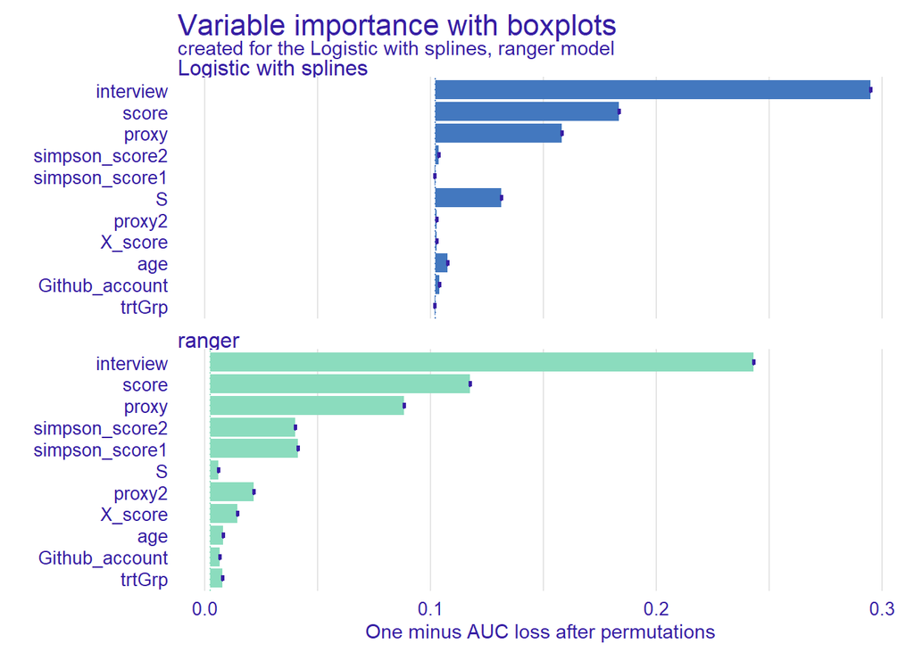

```r
plot(mp_ranger, mp_rms, show_boxplots = TRUE, bar_width = 5) +
  ggtitle("Variable importance with boxplots")
```

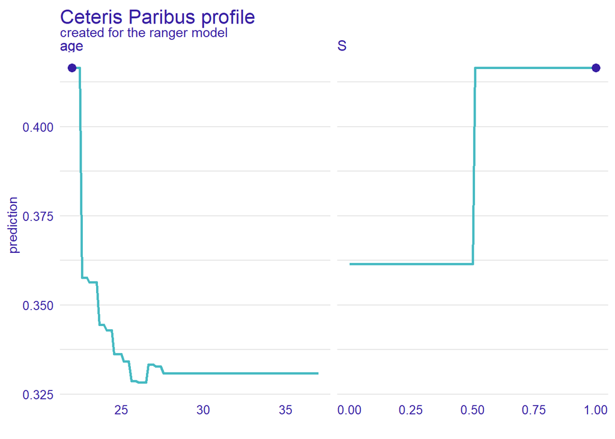

```r
#
# 13. Profiles for a single observation

cp_ranger <- predict_profile(exp_ranger, Sara)

plot(cp_ranger, variables = c("age", "S"))
```

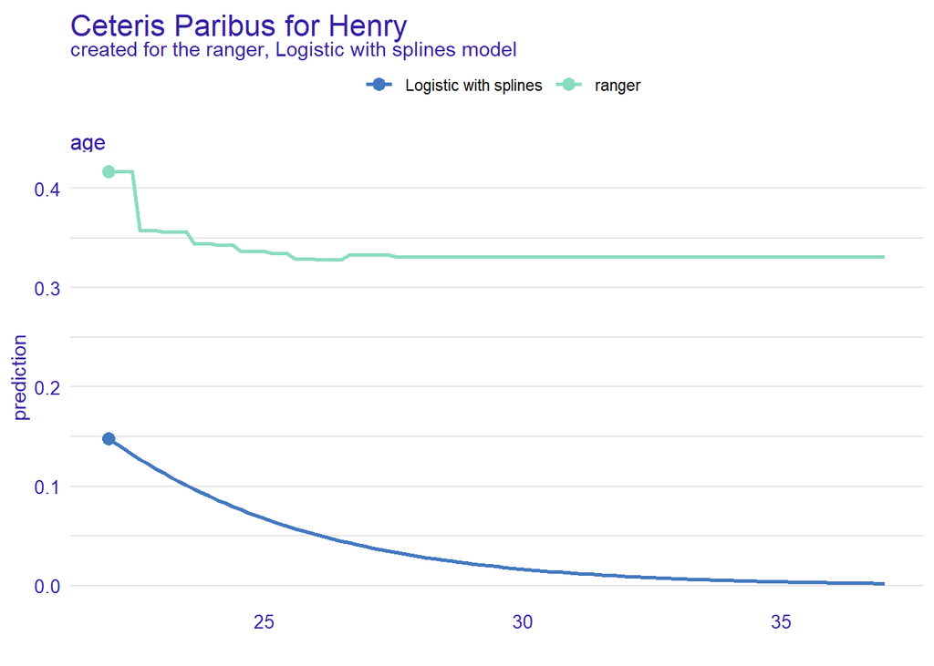

```r
#
# 14. Profiles for two models

cp_rms <- predict_profile(exp_rms, Sara)

plot(cp_ranger, cp_rms, variables = "age", color = "_label_") +
  ggtitle("Ceteris Paribus for Henry")
```

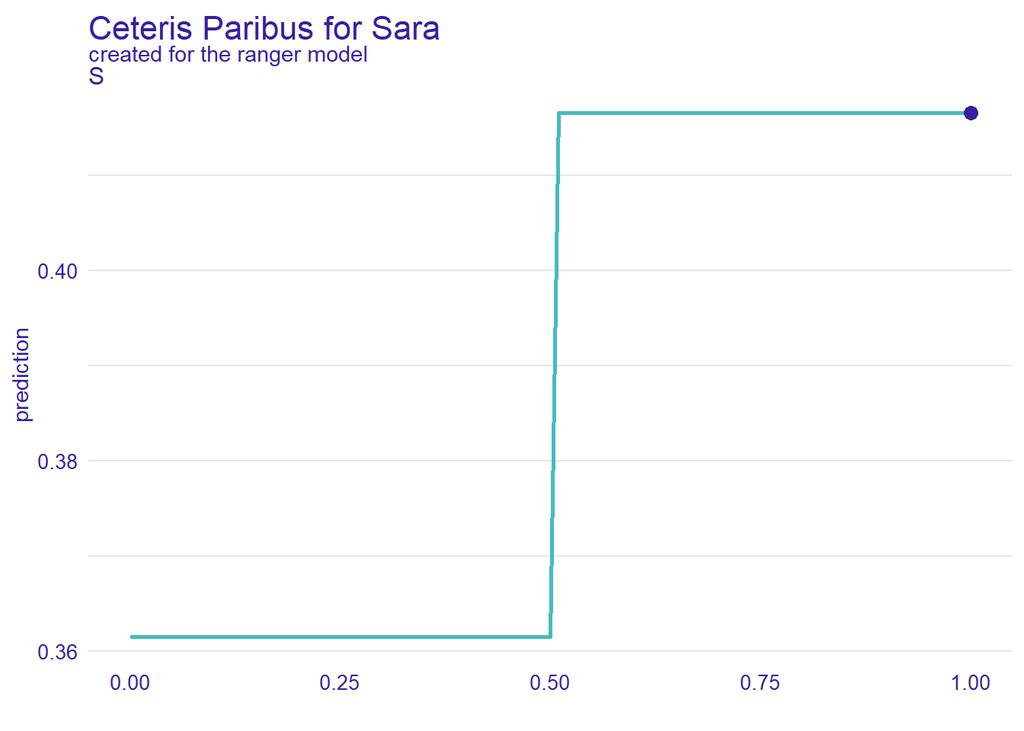

```r
#
# 15. How important are variables

cp_rms <- predict_parts(exp_rms, Sara, type = "oscillations")

#
# 16. For categorical variables

plot(cp_ranger, variables = "S", categorical_type = "bars") +
  ggtitle("Ceteris Paribus for Sara")
```

4/11/2022, aggiornato il 17/11/22, continua con model explanation per altri modelli, usa gli altri scripts per misure basate su curva ROC e confusion matrix.

## Prediction on test set

ottenute le performances e la model explanation nel training set, vediamo come si comportano i modelli nel test set.

```r
# model defined previously
exp_ranger_test <- DALEX::explain(model_ranger,
                      data = data_test[,-11], # test senza risposta
                      y = data_test$Y)
```

```
## Preparation of a new explainer is initiated
##   -> model label       :  ranger  (  default  )
##   -> data              :  2000  rows  11  cols
##   -> target variable   :  2000  values
##   -> predict function  :  yhat.ranger  will be used (  default  )
##   -> predicted values  :  No value for predict function target column. (  default  )
##   -> model_info        :  package ranger , ver. 0.14.1 , task classification (  default  )
##   -> predicted values  :  numerical, min =  0.0004062854 , mean =  0.2921581 , max =  0.9600167
##   -> residual function :  difference between y and yhat (  default  )
##   -> residuals         :  numerical, min =  -0.9506476 , mean =  -0.001158125 , max =  0.9637038
##   A new explainer has been created!
```

```r
predict(exp_ranger_test, data_test[1,])
```

```
##         1
## 0.4521833
```

```r
# Explainer for SVM
exp_svm_test <- DALEX::explain(model_svm,
                      data = data_test[,-11],
                      y = data_test$Y)
```

```
## Preparation of a new explainer is initiated
##   -> model label       :  svm  (  default  )
##   -> data              :  2000  rows  11  cols
##   -> target variable   :  2000  values
##   -> predict function  :  yhat.svm  will be used (  default  )
##   -> predicted values  :  No value for predict function target column. (  default  )
##   -> model_info        :  package e1071 , ver. 1.7.11 , task classification (  default  )
##   -> predicted values  :  numerical, min =  0.01535068 , mean =  0.2859778 , max =  0.9977499
##   -> residual function :  difference between y and yhat (  default  )
##   -> residuals         :  numerical, min =  -0.9927343 , mean =  0.005022165 , max =  0.9782184
##   A new explainer has been created!
```

```r
predict(exp_svm_test, data_test[1,])
```

```
## [1] 0.5028983
```

```r
# with more arguments
exp_rms_test <- DALEX::explain(model_rms,
                   data = data_test[,-11],
                   y = data_test$Y,
                   predict_function = function(m, x)
                     predict(m, x, type = "fitted"),
                   label = "Logistic with splines")
```

```
## Preparation of a new explainer is initiated
##   -> model label       :  Logistic with splines
##   -> data              :  2000  rows  11  cols
##   -> target variable   :  2000  values
##   -> predict function  :  function(m, x) predict(m, x, type = "fitted")
##   -> predicted values  :  No value for predict function target column. (  default  )
##   -> model_info        :  package rms , ver. 6.3.0 , task classification (  default  )
##   -> predicted values  :  numerical, min =  0.0001319463 , mean =  0.2867262 , max =  0.9979555
##   -> residual function :  difference between y and yhat (  default  )
##   -> residuals         :  numerical, min =  -0.9685435 , mean =  0.004273814 , max =  0.9885335
##   A new explainer has been created!
```

```r
#
# 5. The adapter stores some useful information about the model

exp_rms_test$model_info
```

```
## Package: rms
## Package version: 6.3.0
## Task type: classification
```

```r
#
# 6. First step in the exploration are measures of performance
# performance is calculated on data in explainer
# use update_data to set a new dataset

mp_ranger_test <- model_performance(exp_ranger_test)
mp_ranger_test # AUC prossima a 1, sospetta
```

```
## Measures for:  classification
## recall     : 0.6357388
## precision  : 0.7773109
## f1         : 0.6994329
## accuracy   : 0.841
## auc        : 0.8852638
##
## Residuals:
##           0%          10%          20%          30%          40%          50%
## -0.950647619 -0.386235409 -0.238442210 -0.153930883 -0.095305578 -0.055908016
##          60%          70%          80%          90%         100%
## -0.027086032 -0.003229003  0.271340210  0.520998703  0.963703770
```

```r
mp_rms_test <- model_performance(exp_rms_test)
mp_rms_test
```

```
## Measures for:  classification
## recall     : 0.6237113
## precision  : 0.7658228
## f1         : 0.6875
## accuracy   : 0.835
## auc        : 0.8857643
##
## Residuals:
##            0%           10%           20%           30%           40%
## -0.9685434550 -0.3716661201 -0.2203460762 -0.1213087022 -0.0633371398
##           50%           60%           70%           80%           90%
## -0.0319385861 -0.0116917260 -0.0006737584  0.2236239006  0.5400331980
##          100%
##  0.9885335237
```

```r
mp_svm_test <- model_performance(exp_svm_test)
mp_svm_test
```

```
## Measures for:  classification
## recall     : 0.6082474
## precision  : 0.778022
## f1         : 0.6827387
## accuracy   : 0.8355
## auc        : 0.8859994
##
## Residuals:
##          0%         10%         20%         30%         40%         50%
## -0.99273426 -0.30357276 -0.16563541 -0.10855255 -0.07830692 -0.05958914
##         60%         70%         80%         90%        100%
## -0.04494251 -0.02329823  0.17366819  0.55891739  0.97821836
```

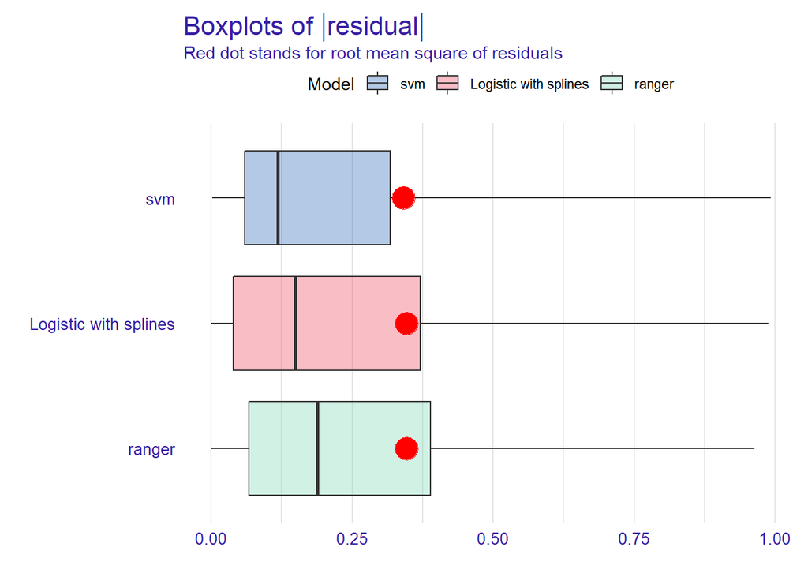

```r
#
# 7. it is easier to compare models with charts

plot(mp_ranger_test, mp_rms_test,mp_svm_test, geom = "boxplot")
```

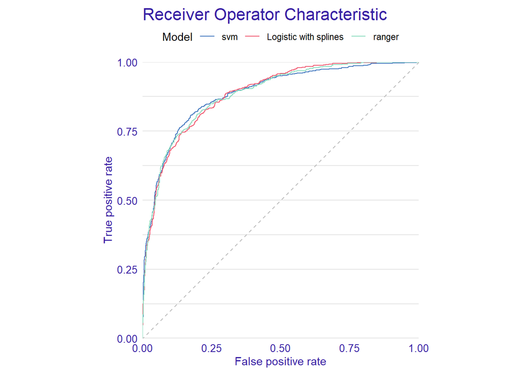

```r
plot(mp_ranger_test, mp_rms_test,mp_svm_test, geom = "roc")
```

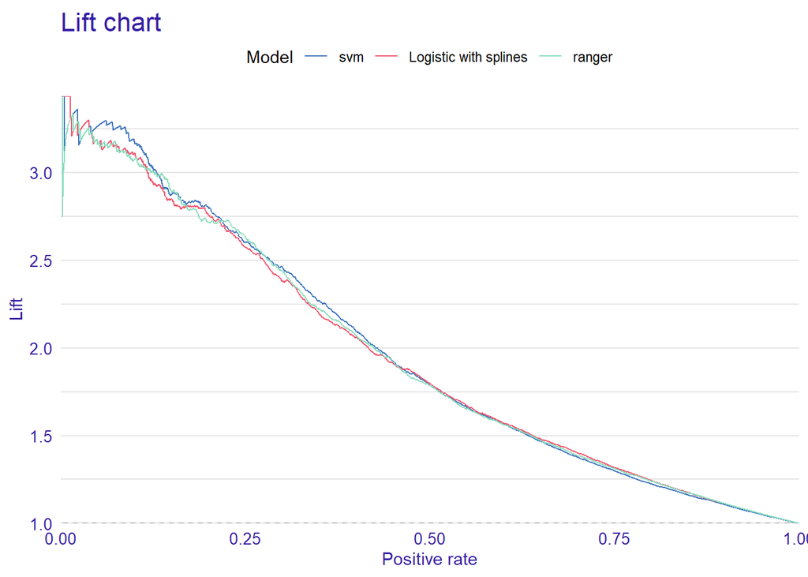

```r
plot(mp_ranger_test, mp_rms_test,mp_svm_test, geom = "lift")
```

```r
#
# 8. Let's focus on a single observations
# loro sono interessanti
# data_train[which(data_train$S==1 & data_train$Y==0),]
use <- data_train[which(data_train$S==1 & data_train$Y==0),]
Test_person<- data_test[33,]
Test_person
```

```
##     S interview Github_account     proxy    proxy2 age X_score score
## 104 0         4              0 -1.772976 0.1702577  22      97     7
##     simpson_score1 simpson_score2 Y trtGrp
## 104      0.2602338     -0.3887973 0      3
```

```r
predict(exp_ranger_test, Test_person)
```

```
##         1
## 0.2428136
```

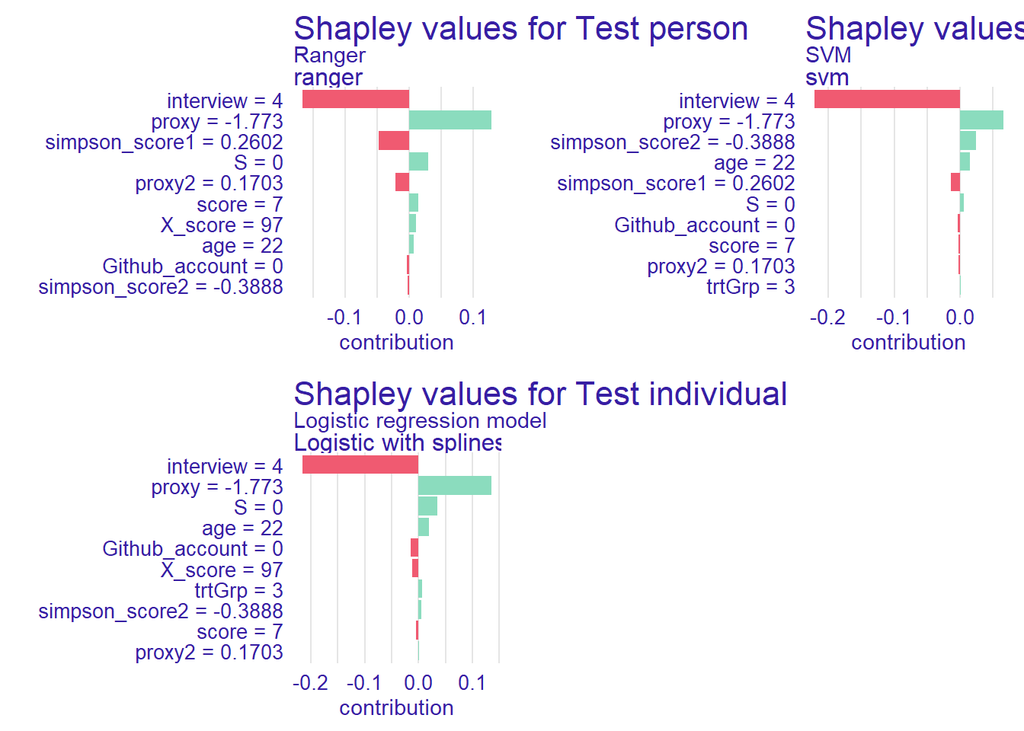

```r
# 9. Variable attributions - Shapley values
# Ranger
sh_ranger_test <- predict_parts(exp_ranger_test, Test_person,
                           type = "shap", B = 1)

sh1 <- plot(sh_ranger_test, show_boxplots = FALSE) +
   ggtitle("Shapley values for Test person","Ranger")

# SVM
sh_SVM_test <- predict_parts(exp_svm_test, Test_person,
                           type = "shap", B = 1)

sh2 <- plot(sh_SVM_test, show_boxplots = FALSE) +
   ggtitle("Shapley values for Test person","SVM")

# Logistic Regression Model
sh_rms_test <- predict_parts(exp_rms_test, Test_person,
                           type = "shap", B = 1)

sh3 <- plot(sh_rms_test, show_boxplots = FALSE) +
   ggtitle("Shapley values for Test individual","Logistic regression model")

ggarrange(sh1,sh2,sh3)
```

Variable attributions - Break-down with specified order in test set

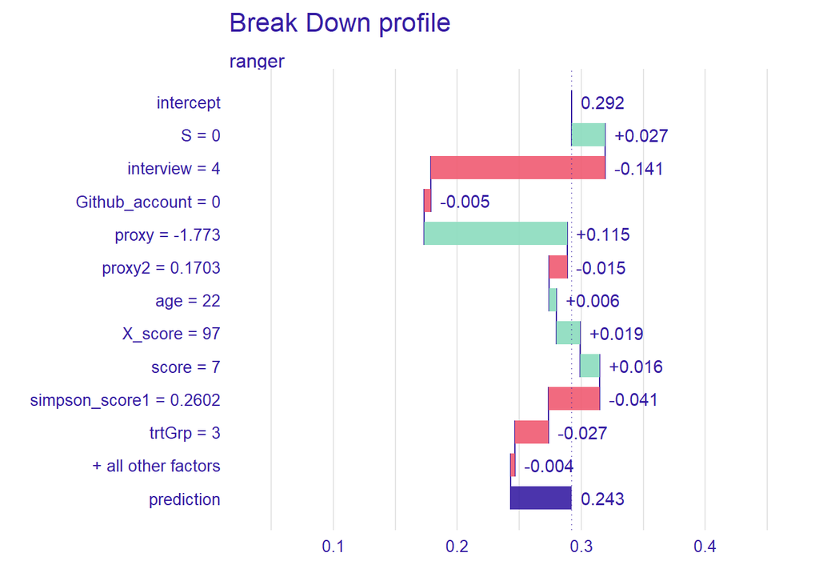

```r
# 11. Variable attributions - Break-down with specified order

bd_ranger_test <- predict_parts(exp_ranger_test, Test_person,
            order = colnames(df))

plot(bd_ranger_test)
```

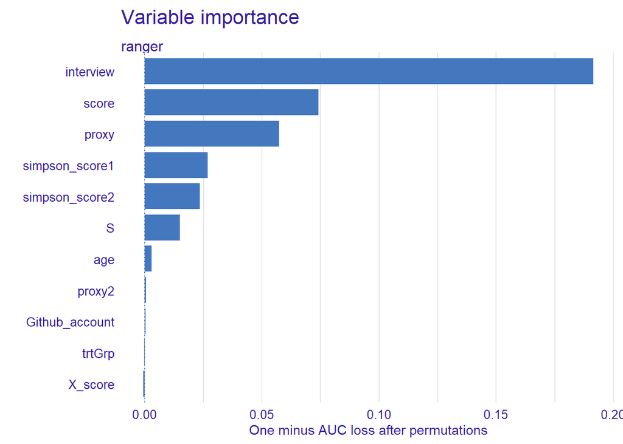

```r
#
# 11. Variable importance

mp_ranger_test <- model_parts(exp_ranger_test, type = "difference")

plot(mp_ranger_test, show_boxplots = FALSE) +
  ggtitle("Variable importance","")
```

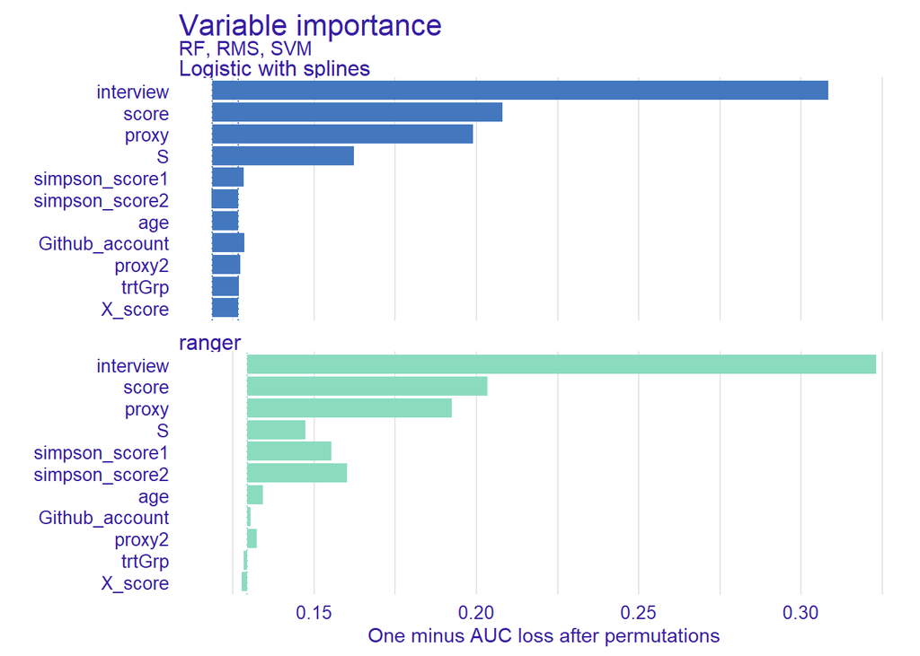

```r
#
# 12. Variable importance for the models in the test set

mp_ranger_test <- model_parts(exp_ranger_test, B = 1)

mp_rms_test <- model_parts(exp_rms_test, B = 1)

mp_svm_test <- model_parts(exp_rms_test, B = 1)

plot(mp_ranger_test, mp_rms_test,mp_svm_test, show_boxplots = FALSE, bar_width = 5) +
  ggtitle("Variable importance","RF, RMS, SVM")
```

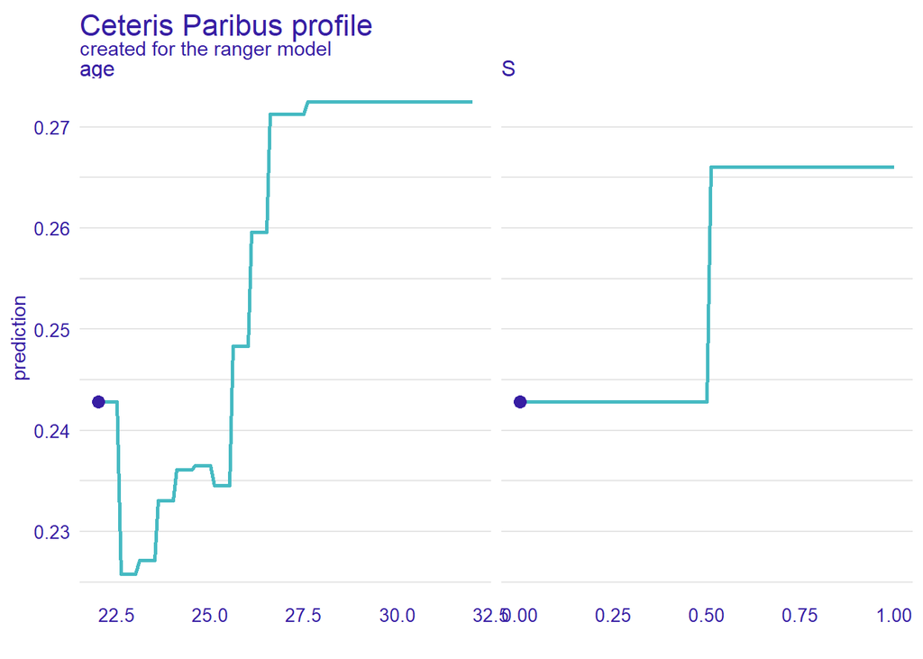

```r
# plot(mp_ranger_test, mp_rms_test,mp_svm_test, show_boxplots = TRUE, # # bar_width = 5) +
# ggtitle("Variable importance with boxplots","RF, RMS, SVM")

#
# 13. Profiles for a single observation

cp_ranger_test <- predict_profile(exp_ranger_test, Test_person)

plot(cp_ranger_test, variables = c("age", "S"))
```

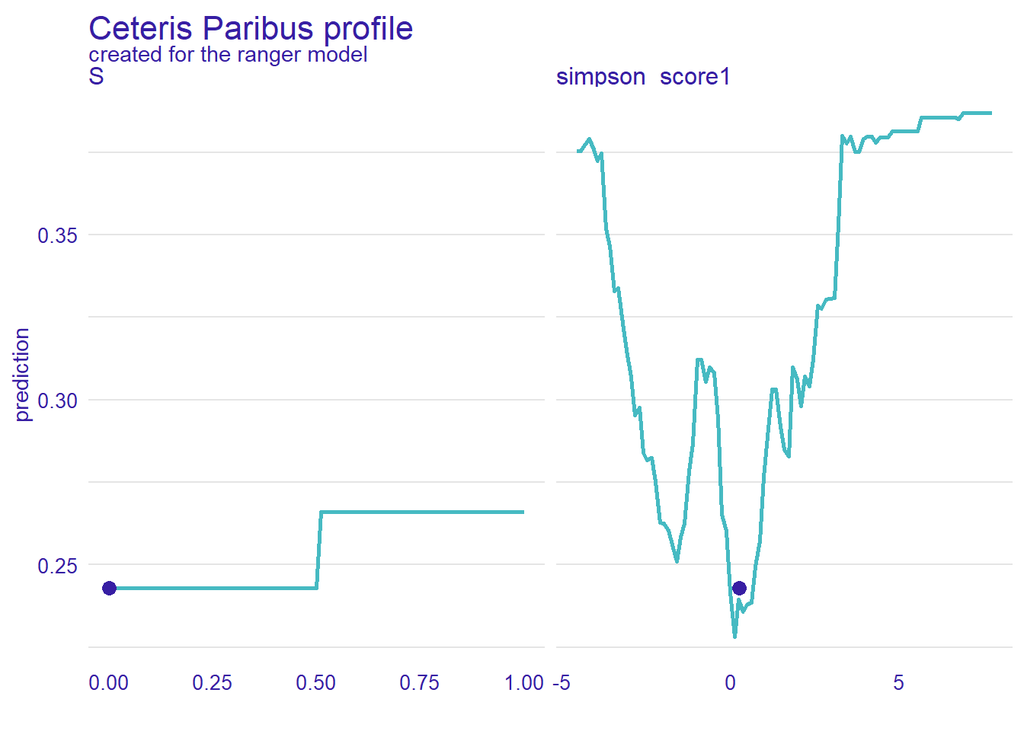

```r
plot(cp_ranger_test, variables = c("simpson_score1", "S"))
```